# 第5回 正則化による多重共線性の問題への対処

光の吸収スペクトルから、肉の脂肪はどこまで分かるか

# 導入

## 第4回は宇宙、今日は食べ物

① 今日のデータ●

- 第4回は、宇宙のデータベースで、銀河の5色の明るさを使った
- 今日は、食品の工場で測る、肉の光のデータを使う
- データの形もくせも違う。データに合わせて、道具を組み立て直す

## 切らずに、みかんの甘さを測る

② 場面●○○○○○○

- 店の「糖度12度以上」のみかんは、選果場で1個ずつ甘さを測っている
- 光を当て、実を通り抜けた光から、糖度を当てる。切らずに、全部の実を測れる
- 光センサー選果機と呼ぶ。みかんの産地の多くの農協が使っている

## 脂肪は、値段と表示を決める

② 場面●●○○○○○

- ひき肉の原料は、脂肪の割合で値段が変わる。赤身が多いほど高い
- 脂肪の上限も決まっている。EUでは、赤身ひき肉は7%以下、牛ひき肉は20%以下
- 工場は、脂の多い肉と赤身の肉を混ぜて、狙いの割合に合わせる

## 化学分析では、間に合わない

② 場面●●●○○○○

- 脂肪を正確に測るには、溶剤で脂を溶かし出して重さを量る（化学分析）
- 1回に数時間かかり、測った肉は捨てることになる
- 工場には、毎日たくさんの肉が流れてくる。その場で、壊さずに測りたい

## 光で、肉の中身を測る

② 場面●●●●○○○

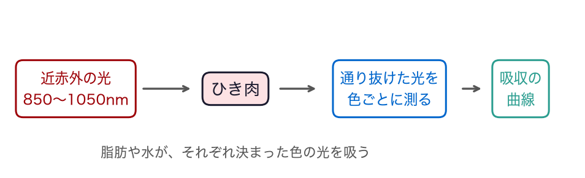

- 肉に近赤外の光を当て、通り抜けた光を色（波長）ごとに測る
- 近赤外分光と呼ぶ。その場で、肉を壊さずに測れる。みかんの選果機も同じ仕組み

## 吸収：光をどれだけ吸ったか

② 場面●●●●●○○

- 脂肪や水は、それぞれ決まった波長の光をよく吸う
- 吸収は、その波長の光をどれだけ吸ったかの量。大きいほど、よく吸った
- 波長ごとの吸収を並べた曲線を、スペクトルと呼ぶ

## 決めたいこと

② 場面●●●●●●○

- 化学分析した肉を手がかりに、光のスペクトルから脂肪の割合を当てる式を作りたい
- 一度式ができれば、あとは光だけで測れる
- できれば、どの波長が脂肪を教えているかも知りたい

## 答えのある肉は、少ししか作れない

② 場面●●●●●●●

- 式を作るには、光と化学分析の両方で測った肉が要る
- 化学分析は高くて遅いので、そういう肉は少ししか用意できない
- 一方で、波長は100本。少ない肉で、たくさんの列を扱うことになる

## 手元のデータ

③ 手元のデータ●○○○

- Tecator（テカトール）社の装置で測った、ひき肉240個のデータ
- 1行が1個の肉。850〜1048nmを2nmおきに、100本の波長の吸収
- 答えの列は、化学分析で測った脂肪・水分・たんぱく質の割合（%）

## データをのぞく

③ 手元のデータ●●○○

|  | 850 | 852 | 854 | 1046 | 1048 | 水分 | 脂肪 | たんぱく質 |
| --- | --- | --- | --- | --- | --- | --- | --- | --- |
| 0 | 2617.76 | 2618.14 | 2618.59 | 2839.40 | 2819.20 | 60.5 | 22.5 | 16.7 |
| 1 | 2834.54 | 2838.71 | 2842.83 | 3196.00 | 3179.42 | 46.0 | 40.1 | 13.5 |
| 2 | 2582.84 | 2584.58 | 2586.29 | 2564.04 | 2548.16 | 71.0 | 8.4 | 20.5 |
| 3 | 2822.86 | 2824.60 | 2826.30 | 2816.17 | 2796.22 | 72.8 | 5.9 | 20.7 |
| 4 | 2788.13 | 2789.89 | 2791.67 | 3157.70 | 3137.53 | 58.3 | 25.5 | 15.5 |

- 列が100本並ぶ。1行の100個の数を並べると、1本の曲線になる

## 1行が1本のスペクトル

③ 手元のデータ●●●○

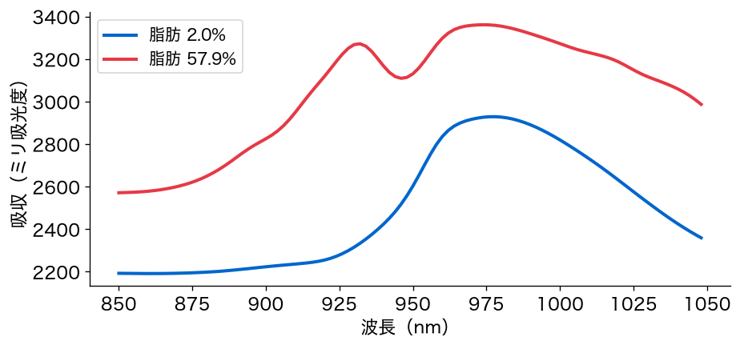

- 脂肪の少ない肉と多い肉。曲線の高さも形も、少しずつ違う

## 今日は120個だけ使う

③ 手元のデータ●●●●

- 化学分析できたのは120個だけ、という場面にする
- 240個から、くじで120個を抜き出して使う
- 第4回の「分光できたのは1,000個だけ」と同じ形

## 第4回で残したこと

④ 今日の問い●○○

- 第4回は、5色を色の差に作り直して、係数を読める式にした
- でも、いつも作り直し方が分かるとは限らない
- 今日の列は100本。似た列もたくさんある

## 最後に出す答え

④ 今日の問い●●○

- 光のスペクトルから、脂肪の割合をどれくらいの外れで当てられるか
- どの波長が、脂肪を教えているか

## 今日の問い

④ 今日の問い●●●

光の吸収スペクトルから、肉の脂肪はどこまで分かるか？

## もう1つのねらい：辞書

⑤ もう1つのねらい●

- くり返しの結果を辞書にため、名前で引けるようになる
- ペナルティの強さαごとのMAEや、波長ごとに選ばれた回数を、名前つきでためる

# 今日の一周

## 結果だけで一度通す

⑥ 今日の一周●○○○○○○○

- まず、今日の解析を、結果だけで一度通して見る
- コードはあとで。どんな結論になるかを先に知っておく

## 一周①：100本で当てる

⑥ 今日の一周●●○○○○○○

- 100本の波長で式を作ると、脂肪は平均3.0%の外れで当たる
- でも係数は、隣の波長どうしで+と−に暴れる

## 一周②：ペナルティをかけて縮める

⑥ 今日の一周●●●○○○○○

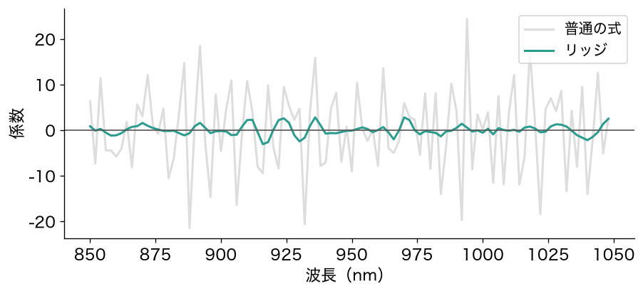

- 係数にペナルティをかける（リッジ）と、外れは1.98%に減り、係数も落ち着く

## 一周③：効く波長だけ残す？

⑥ 今日の一周●●●●○○○○

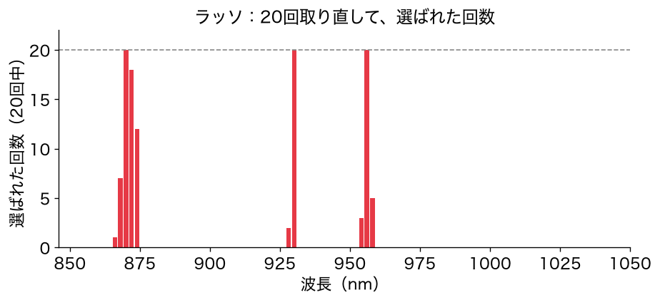

- ラッソは数本に絞る。でも取り直すたびに、選ぶ波長が隣と入れ替わる

## 一周④：束で残す

⑥ 今日の一周●●●●●○○○

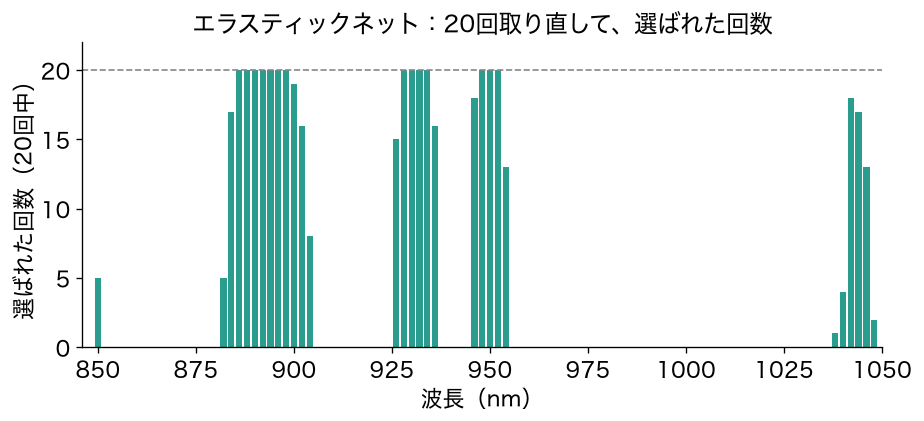

## 一周⑤：つまみ2つを探す

⑥ 今日の一周●●●●●●○○

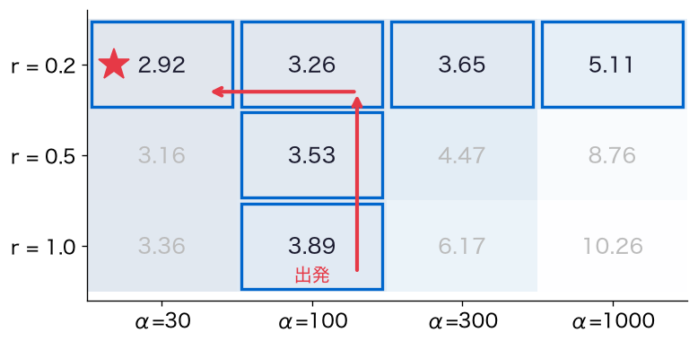

- αとr、2つのつまみを交差検証で探す。全部の組を試すか、1つずつ動かすか

## 一周⑥：えっ、930nm

⑥ 今日の一周●●●●●●●○

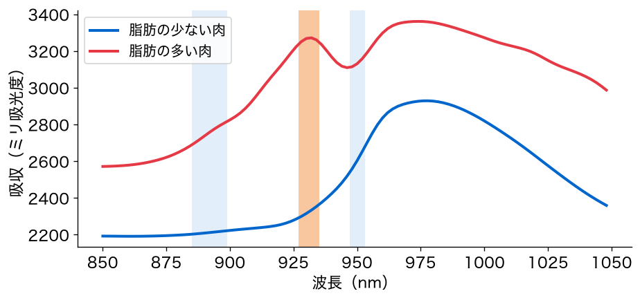

- 残った帯の1つ（橙）は930nmのまわり。脂肪が光を吸う波長として知られる
- データだけで、化学の知識と同じ場所を見つけた

## 一周は6つの段

⑥ 今日の一周●●●●●●●●

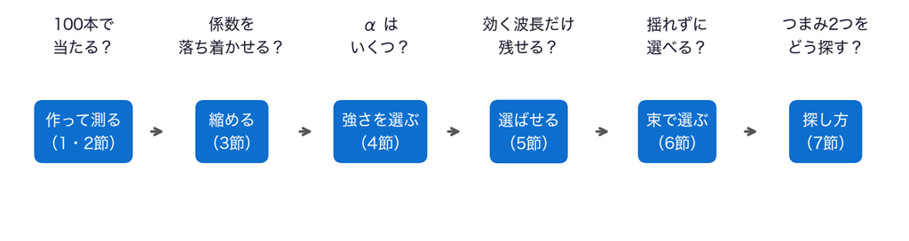

- このあと、6つの段の中身を、1つずつ開けていく

## 問いとやること①②

⑦ 問いとやること●○○

- 作って測る：100本で当たる？ → 100本の波長で式を作り、交差検証で外れを測って、係数を描く（1・2節）
- 縮める：係数を落ち着かせられる？ → 係数にペナルティをかける式（リッジ）で、外れと係数を比べる（3節）

## 問いとやること③④

⑦ 問いとやること●●○

- 強さを選ぶ：αはいくつ？ → αを動かし、交差検証のMAEを辞書にためて選ぶ（4節）
- 選ばせる：効く波長だけ残せる？ → ラッソで絞り、20回取り直して、選ばれた回数を数える（5節）

## 問いとやること⑤⑥

⑦ 問いとやること●●●

- 束で選ぶ：揺れずに選べる？ → エラスティックネットで帯を残し、20回取り直して数える（6節）
- 探し方：つまみ2つをどう探す？ → αとrを、全部の組で試す方法と、1つずつ動かす方法で探す（7節）

## 今日の進め方

⑧ 今日の進め方●

- 段ごとに、スライドで聞く → ノートで実行して答える
- 段の終わりの「ノートへ」で、予想を書き、1か所を替えて実行し、予想と比べる
- 予想は外れてかまわない

# 0. 準備

## まずは道具とデータ

- 0節は、ノートで1節と続けて実行する
- 道具を呼び出す → 表を読み込む → 120個を抜き出す

## お手本：120個を抜き出す

0節 ① 120個を抜き出す●○

```python
waves = list(raw.columns[:100])     # 波長の列の名前（100本）
nm = list(range(850, 1050, 2))      # 波長の数（図の横軸）
raw[waves] = raw[waves] * 1000      # ミリ吸光度に直す
df = raw.sample(120, random_state=0).reset_index(drop=True)
print(len(df), '個')
print(df['脂肪'].describe().round(1))
```

```
120 個
count    120.0
mean      18.5
std       14.9
min        2.0
25%        6.8
50%       12.2
75%       28.2
max       57.9
```

## 脂肪は2%から58%まで

0節 ① 120個を抜き出す●●

- 脂肪の割合は2.0〜57.9%、中央値は12.2%
- 吸収は1000倍して、ミリ吸光度という単位にした（分光でよく使う）

# 1. 100本で式を作る

## 段1：作って測る

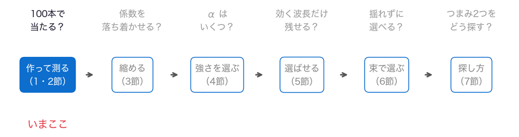

- 問い：100本の波長で、脂肪はどのくらい当たるか
- まず、第4回と同じ手順で、式を作って交差検証で測る

## 式の形

1節 ① 式を作る●○

$$\hat{y}_i = b_0 + b_1 x_{i1} + b_2 x_{i2} + \cdots + b_{100} x_{i,100}$$

- $x_{i1}, \dots, x_{i,100}$は$i$番目の肉の、100本の波長の吸収
- $b_1, \dots, b_{100}$が係数、$\hat{y}_i$が脂肪の割合の予測

## おさらい：交差検証

1節 ① 式を作る●●

- 肉を5つの組に分け、1つずつテストにして、5回MAEを測る
- 5回のMAEを平均する。どの肉も、ちょうど1度ずつテストに入る
- 2つの式は、同じ組どうしで比べる（第4回）

## お手本：交差検証の関数

1節 ② 交差検証の関数●○

```python
df['組'] = df.index % 5

def cv_mae(df, cols, model):
    maes_k = []
    for k in range(5):
        tr_k = df[df['組'] != k]      # 組k以外で訓練
        te_k = df[df['組'] == k]      # 組kでテスト
        model.fit(tr_k[cols], tr_k['脂肪'])
        pred_k = model.predict(te_k[cols])
        maes_k.append(np.abs(te_k['脂肪'] - pred_k).mean())
    return maes_k
```

- 第4回の`cv_mae`と同じ流れ。式の作り方`model`も、引数で渡す

## 道具も引数で渡せる

1節 ② 交差検証の関数●●

- `model`に`LinearRegression()`を渡せば、普通の線形回帰
- このあと、ほかの式の作り方を渡すだけで、同じ物差しで比べられる
- 引数で渡した道具も、関数の中で`fit`と`predict`が使える

## お手本：100本で交差検証

1節 ③ 100本で測る●○○

```python
cv_ols = cv_mae(df, waves, LinearRegression())
print(np.round(cv_ols, 2), round(np.mean(cv_ols), 2))
base = np.abs(df['脂肪'] - df['脂肪'].mean()).mean()
print(round(base, 2))               # 平均で当てたとき
```

```
[2.55 4.35 2.92 2.99 2.18] 3.0
12.24
```

## 平均で当てると12.24%

1節 ③ 100本で測る●●○

- 100本の波長の式では、脂肪の割合は平均3.0%の外れ
- どの肉も平均の18.5%と当てると、外れは平均12.24%
- 光だけで、外れを4分の1まで縮めた

## 訓練では、ほぼ当たる

1節 ③ 100本で測る●●●

```python
tr_0 = df[df['組'] != 0]
m_0 = LinearRegression().fit(tr_0[waves], tr_0['脂肪'])
err_0 = np.abs(tr_0['脂肪'] - m_0.predict(tr_0[waves]))
print(round(err_0.mean(), 2))
```

```
0.69
```

- 訓練の96個では外れ0.69%。テストでは3.0%
- 式を作った肉に合わせすぎている（第2回の過学習）

# 2. 係数は読める？

## 当たる式の、中身を読む

- 外れ3.0%の式ができた。次は、どの波長が脂肪を教えているかを読む
- 係数を、波長に沿って描いてみる

## お手本：係数を波長に沿って描く

2節 ① 係数を描く●○

```python
m_ols = LinearRegression().fit(df[waves], df['脂肪'])
print(round(m_ols.coef_.min(), 1), round(m_ols.coef_.max(), 1))
plt.plot(nm, m_ols.coef_)
plt.axhline(0, color='gray')
plt.xlabel('波長（nm）')
plt.ylabel('係数')
plt.show()
```

## 隣どうしで+と−が入れ替わる

2節 ① 係数を描く●●

```
係数 -21.5 〜 24.4  符号が入れ替わった回数 62
```

- 係数は−21.5〜+24.4の間で、隣どうし99か所のうち62か所で符号が入れ替わる
- 「930nmの吸収が1増えると、脂肪が〇%増える」とは、とても読めない

## お手本：組ごとの930nmの係数

2節 ② 係数の揺れ●○

```python
def coef_at(model, k, w):
    tr_k = df[df['組'] != k]
    model.fit(tr_k[waves], tr_k['脂肪'])
    return pd.Series(model.coef_, index=waves)[w]

c930_ols = []
for k in range(5):
    c930_ols.append(coef_at(LinearRegression(), k, '930'))
print(np.round(c930_ols, 1))
```

```
[ -1.2  -1.3  13.9 -14.7   2.7]
```

- 組`k`以外で式を作り、波長`w`の係数を返す。第4回の`r_coef`と同じ形

## 作るたびに、符号まで変わる

2節 ② 係数の揺れ●●

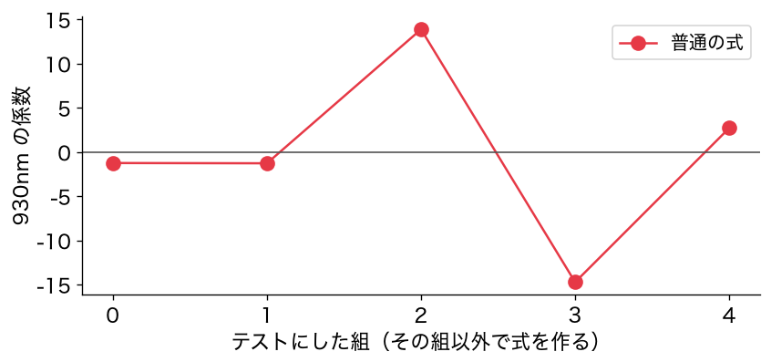

- 930nmの係数は、組を替えるだけで−14.7〜+13.9と揺れる

## 隣の波長は、ほとんど同じ

2節 ③ 多重共線性●○○

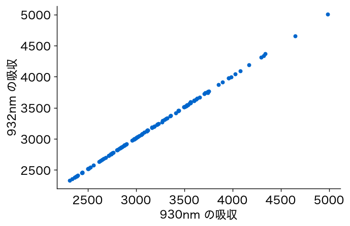

```
930nmと932nmの相関 0.99997
100本どうしの相関の最小 0.959
```

## 第4回の多重共線性

2節 ③ 多重共線性●●○

- 100本どうしの相関は、いちばん小さくても0.959
- 似た列が100本も並ぶので、係数は手柄を分けられず、揺れる
- 第4回の、rとiの関係が、100本で起きている

## 重要：予測と係数は別

2節 ③ 多重共線性●●●

相関の強い列がたくさんあると、予測はそこそこ当たっても、係数は揺れて読めない。

## TODO①：使う波長を替える

2節 ④ 使う波長●

```python
# TODO: ['930'] を ['930', '932', '934'] に替えて実行する
cols_x = ['930']
print(round(np.mean(cv_mae(df, cols_x, LinearRegression())), 2))
m_x = LinearRegression().fit(df[cols_x], df['脂肪'])
print(m_x.coef_.round(1))
```

- 予想：930nmの1本だけで当てると？ 隣の3本にすると？

## ここまでで分かったこと

2節 ⑤ 分かったこと●

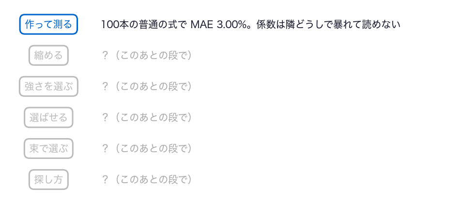

- まだ分からない：係数を落ち着かせて、読める式にできるか

## ノートへ：0〜2節

2節 ⑥ ノートへ●

- 0〜2節のセルを上から実行し、スライドと同じ数が出るか確かめる
- TODO①：予想を書く → `['930']`を`['930', '932', '934']`に替えて実行 → 予想と比べる

動画の人は、ここで一時停止。

## 答え合わせ：TODO①

2節 ⑦ 答え合わせ●○

```
930nmだけ    10.07
隣の3本      3.11 [-3.3  6.6 -3.3]
```

- 1本だけでは10.07%で、平均で当てるのとほぼ同じ
- 隣の3本にすると3.11%。100本の式（3.0%）に近い

## 3本で、山の形を見ている

2節 ⑦ 答え合わせ●●

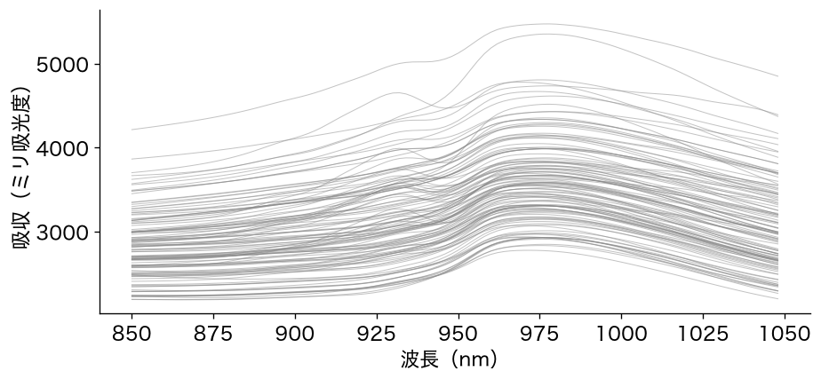

- 1本の高さは、肉の厚みなどで上下して、脂肪を教えてくれない
- 係数−3.3、+6.6、−3.3は足すと0。全体の上下を消し、932nmの尖り具合を見ている

# 3. 係数にペナルティをかける

## 段2：縮める

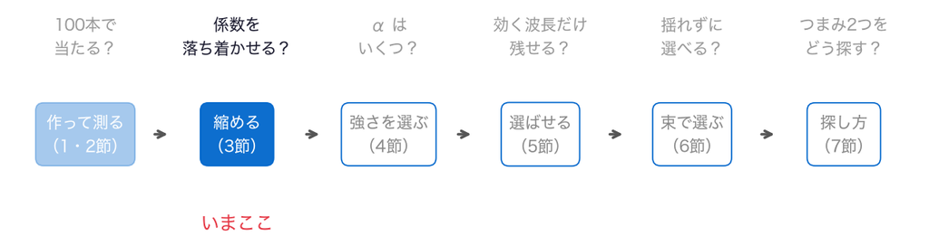

- 問い：係数を落ち着かせて、読める式にできるか
- 100本の係数は−21.5〜+24.4で暴れ、作るたびに符号まで変わった

## 前の段から

3節 ① 前の段から●

- 隣の3本なら、係数は−3.3、+6.6、−3.3で落ち着いていた
- でも、どの3本がよいかは、前もって分からない
- 100本のまま、係数だけを落ち着かせられないか

## 係数を決める基準

3節 ② ペナルティをかける●○

$$\sum_{i=1}^{n} (y_i - \hat{y}_i)^2$$

- 普通の式は、外れの二乗の和が最小になるように係数を決めた（第2回）
- 似た列が多いと、大きな+と大きな−を組み合わせて、訓練に合わせ込む

## ペナルティを足す

3節 ② ペナルティをかける●●

$$\sum_{i=1}^{n} (y_i - \hat{y}_i)^2 + \alpha \sum_{j=1}^{100} b_j^2$$

- 係数の二乗の和に、$\alpha$を掛けて足す。係数が大きいほど、ペナルティが重い
- 外れを小さくしたいが、係数も大きくしたくない。その折り合いで決める

## 係数1つで見ると

3節 ③ 谷が動く●○○○

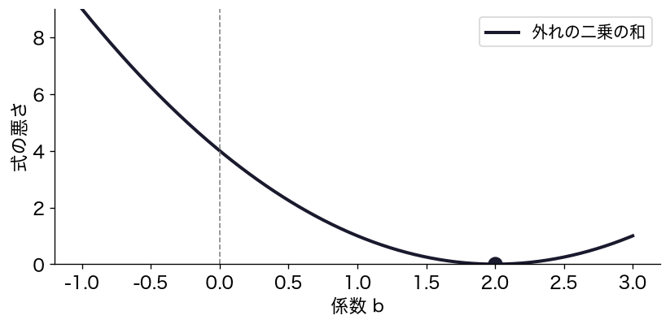

- ペナルティなしでは、谷底（いちばん外れが小さい係数）は$b = 2$

## ペナルティで、谷底が0へ寄る

3節 ③ 谷が動く●●○○

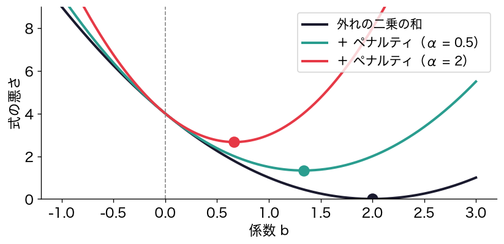

- $\alpha$を大きくするほど、谷底は0に近づく。係数が縮む

## 名前：正則化とリッジ

3節 ③ 谷が動く●●●○

- 係数にペナルティをかけて縮めることを、正則化（regularization）と呼ぶ
- 二乗の和のペナルティをかけた線形回帰を、リッジ回帰（ridge）と呼ぶ
- $\alpha$はペナルティの強さ。0なら普通の式、大きいほど係数は0に近づく

## なぜ縮めると落ち着くか

3節 ③ 谷が動く●●●●

- 似た2本に、+20と−20をつけても、0.1と0.1をつけても、予測はほぼ同じ
- ペナルティがあると、大きな+と−の組み合わせは損になる
- 似た列どうしで、手柄を小さく分け合う係数が選ばれる

## お手本：リッジで交差検証

3節 ④ リッジで測る●○

```python
cv_r = cv_mae(df, waves, Ridge(alpha=1))
print(np.round(cv_r, 2), round(np.mean(cv_r), 2))
print(np.round(cv_ols, 2), round(np.mean(cv_ols), 2))
```

```
[1.62 1.93 2.14 2.15 2.05] 1.98
[2.55 4.35 2.92 2.99 2.18] 3.0
```

- `Ridge(alpha=1)`：ペナルティの強さ1のリッジ。`cv_mae`に渡すだけ

## 5つの組すべてで、外れが減る

3節 ④ リッジで測る●●

- リッジは平均1.98%、普通の式は3.0%
- 組ごとに比べても、5つの組すべてでリッジの外れが小さい
- ペナルティをかけると、訓練への合わせすぎが抑えられる

## お手本：係数を描き比べる

3節 ⑤ 係数が落ち着く●○○○

```python
m_r = Ridge(alpha=1).fit(df[waves], df['脂肪'])
print(round(m_r.coef_.min(), 2), round(m_r.coef_.max(), 2))
plt.plot(nm, m_ols.coef_, color='lightgray', label='普通の式')
plt.plot(nm, m_r.coef_, label='リッジ')
plt.axhline(0, color='gray')
plt.xlabel('波長（nm）')
plt.ylabel('係数')
plt.legend()
plt.show()
```

## 係数が縮み、なめらかに

3節 ⑤ 係数が落ち着く●●○○

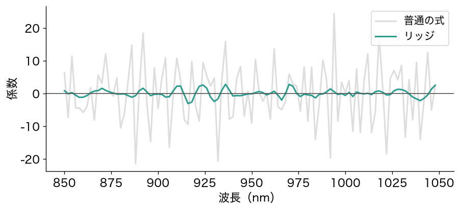

```
リッジの係数 -3.12 〜 2.77
```

## 作り直しても、同じ向き

3節 ⑤ 係数が落ち着く●●●○

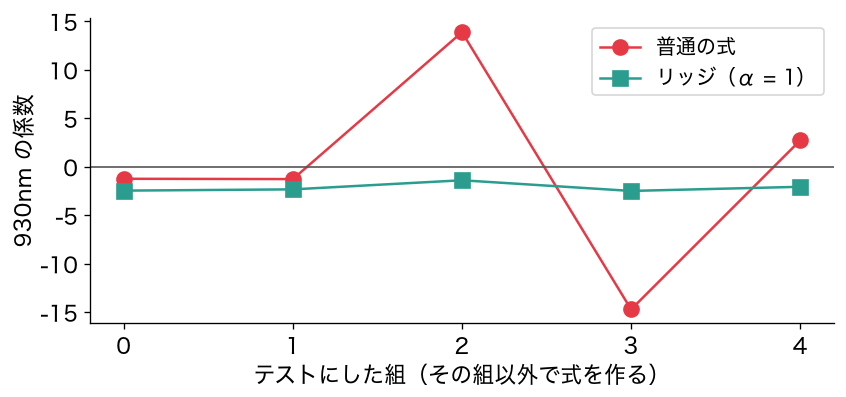

```
リッジの930nmの係数 [-2.45 -2.32 -1.39 -2.49 -2.06]
```

- 930nmの係数は、5回とも−2.49〜−1.39のマイナスで、揺れが小さい

## 重要：正則化

3節 ⑤ 係数が落ち着く●●●●

列が多くて係数が暴れるときは、ペナルティをかけて縮める（正則化）。

## TODO②：肉の数を替える

3節 ⑥ 肉の数●

```python
# TODO: 120 を 240 に替えて実行する
df_n = raw.sample(120, random_state=0).reset_index(drop=True)
df_n['組'] = df_n.index % 5
print(round(np.mean(cv_mae(df_n, waves, LinearRegression())), 2))
print(round(np.mean(cv_mae(df_n, waves, Ridge(alpha=1))), 2))
```

- 予想：肉を240個に増やすと、普通の式とリッジの差はどうなる？

## ここまでで分かったこと

3節 ⑦ 分かったこと●

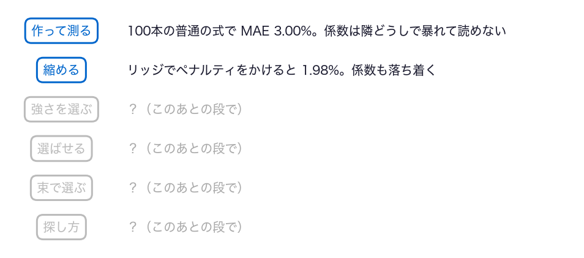

- まだ分からない：$\alpha$を1にしたのは、なぜか

## ノートへ：3節

3節 ⑧ ノートへ●

- 3節のセルを上から実行し、スライドと同じ数が出るか確かめる
- TODO②：予想を書く → `120`を`240`に替えて実行 → 予想と比べる

動画の人は、ここで一時停止。

## 答え合わせ：TODO②

3節 ⑨ 答え合わせ●○

```
120個  普通の式 3.0  リッジ 1.98
240個  普通の式 1.82  リッジ 1.77
```

- 240個では、普通の式1.82%、リッジ1.77%。差はほとんど消える

## 重要：効き目はデータしだい

3節 ⑨ 答え合わせ●●

データが少なく列が多いほど、ペナルティが効く。データが増えれば、普通の式でも係数が決まりやすくなる。

# 4. αはいくつ？

## 段3：強さを選ぶ

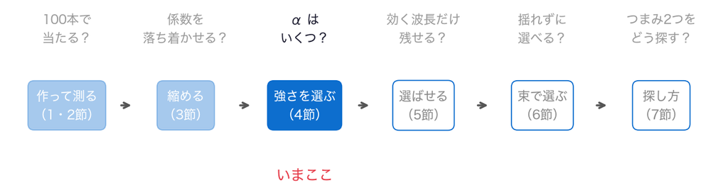

- 問い：ペナルティの強さ$\alpha$は、いくつにすればよいか
- 3節では、$\alpha = 1$と決め打ちした

## 前の段から

4節 ① 前の段から●

- 肉が少ないうちは、ペナルティをかけると外れが減り、係数も落ち着いた
- ペナルティが弱すぎれば、普通の式と同じ。強すぎれば、係数がみな0に近づく
- ちょうどよい強さは、どう決めるか

## 係数と、αの違い

4節 ② ハイパーパラメータ●○

- 係数$b_j$は、`fit`がデータから決める
- $\alpha$は、`fit`の前に、人が決めて渡す
- 人が決める設定を、ハイパーパラメータ（hyperparameter）と呼ぶ

## 候補を並べて、交差検証で比べる

4節 ② ハイパーパラメータ●●

- $\alpha$の候補を並べ、それぞれで交差検証のMAEを測る
- いちばんMAEの小さい$\alpha$を選ぶ。これをチューニング（tuning）と呼ぶ
- 第4回の交差検証が、そのまま選ぶ道具になる

## 結果を、名前でためたい

4節 ③ 辞書●○

- 第4回は、くり返しの結果をリストにためた
- リストは、0番目・1番目…と順番で引く
- 今日は「$\alpha = 10$のときのMAE」と、$\alpha$の値で引きたい

## 新しい書き方：辞書

4節 ③ 辞書●●

```python
d = {}             # 空の辞書
d['りんご'] = 120   # 名札'りんご'に120をしまう
d['みかん'] = 80    # 名札'みかん'に80をしまう
print(d['みかん'])  # 80
```

- 名札（キー）と中身（値）の組をためる入れ物が、辞書
- `d[キー] = 値`でしまい、`d[キー]`で取り出す

## お手本：αごとのMAEを辞書に

4節 ④ 辞書にためる●○○○○○

```python
maes = {}
for a in [0.01, 0.1, 1, 10, 100, 1000]:
    maes[a] = np.mean(cv_mae(df, waves, Ridge(alpha=a)))
for a in maes:
    print(a, round(maes[a], 2))
```

```
0.01 2.33
0.1 2.02
1 1.98
10 2.33
100 2.51
1000 2.52
```

- `for a in maes:`で、辞書の名札を1つずつ取り出す

## 名札のついた引き出し

4節 ④ 辞書にためる●●○○○○

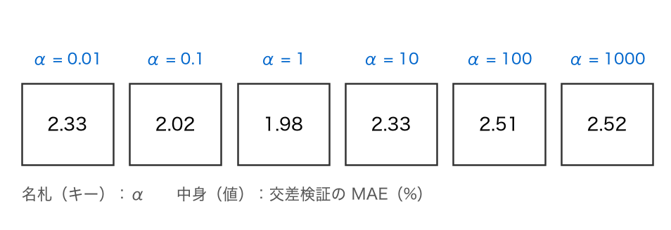

- 1回まわるたびに、名札$\alpha$の引き出しが1つ増え、MAEがしまわれる
- `maes[1]`で、$\alpha = 1$の引き出しを開ける

## 1行ずつ：MAEを辞書に①

4節 ④ 辞書にためる●●●○○○

```python
maes = {}
for a in [0.01, 0.1, 1, 10, 100, 1000]:
    maes[a] = np.mean(cv_mae(df, waves, Ridge(alpha=a)))
for a in maes:
    print(a, round(maes[a], 2))
```

- 1行目：空の辞書を作り、`maes`と名付ける
- 2行目：`a`に0.01、0.1、…、1000を順に入れ、字下げした3行目をくり返す

## 1行ずつ：MAEを辞書に②

4節 ④ 辞書にためる●●●●○○

```python
maes = {}
for a in [0.01, 0.1, 1, 10, 100, 1000]:
    maes[a] = np.mean(cv_mae(df, waves, Ridge(alpha=a)))
for a in maes:
    print(a, round(maes[a], 2))
```

- 3行目：右側で、そのαのリッジを交差検証で測り、5つの組のMAEを平均する
- その平均を、名札`a`の引き出しにしまう（`maes[a] = 値`）
- 名札は0番目・1番目ではなく、αの値そのもの

## 1行ずつ：MAEを辞書に③

4節 ④ 辞書にためる●●●●●○

```python
maes = {}
for a in [0.01, 0.1, 1, 10, 100, 1000]:
    maes[a] = np.mean(cv_mae(df, waves, Ridge(alpha=a)))
for a in maes:
    print(a, round(maes[a], 2))
```

- 4行目：`for a in maes:`で、辞書の名札を、しまった順に1つずつ取り出す
- 5行目：`maes[a]`で、名札`a`の引き出しを開け、小数2桁に丸めて出す

## 中身を見る：2回まわした辞書

4節 ④ 辞書にためる●●●●●●

```python
maes2 = {}
for a in [0.01, 0.1]:
    maes2[a] = np.mean(cv_mae(df, waves, Ridge(alpha=a)))
    print(list(maes2.keys()), round(maes2[a], 2))
```

```
[0.01] 2.33
[0.01, 0.1] 2.02
```

- `list(maes2.keys())`は、名札の並び。1回まわるたびに、名札が1つ増える
- 名札0.01の中身は2.33、名札0.1の中身は2.02

## お手本：αとMAEを描く

4節 ⑤ 谷を探す●○○

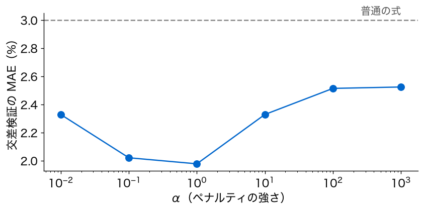

```python
plt.plot(list(maes.keys()), list(maes.values()), 'o-')
plt.xscale('log')
plt.xlabel('α（ペナルティの強さ）')
plt.ylabel('交差検証のMAE（%）')
plt.show()
```

## 強すぎても、弱すぎても悪い

4節 ⑤ 谷を探す●●○

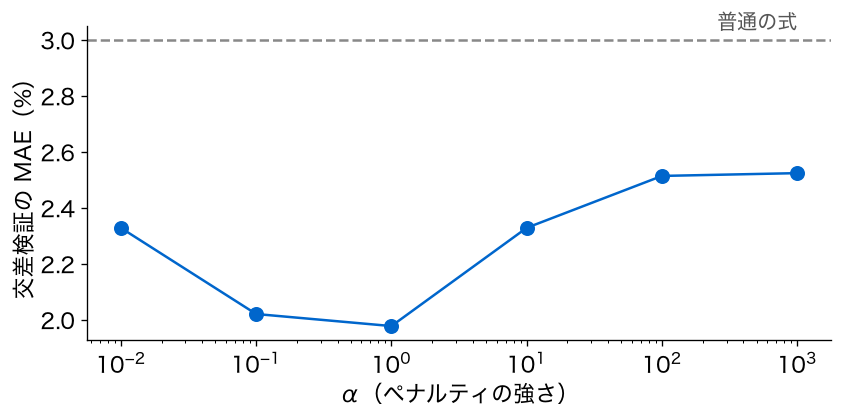

- `keys()`は名札の並び、`values()`は中身の並び。`plt.xscale('log')`で横軸を10倍ごとに
- $\alpha = 1$の1.98%がいちばん小さい。両側で外れが増える

## お手本：いちばん小さいα

4節 ⑤ 谷を探す●●●

```python
best_a = min(maes, key=maes.get)
print(best_a, round(maes[best_a], 2))
```

```
1 1.98
```

- 名札の中から、中身（MAE）がいちばん小さい名札を選ぶ

## αを動かすと、係数はどう動く？

4節 ⑥ 解パス●○

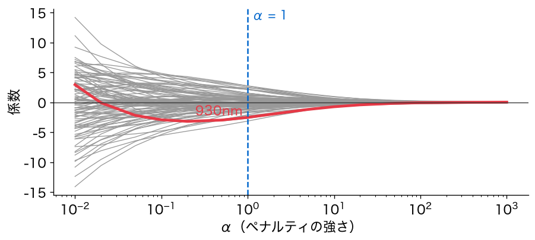

- αを動かしたときの係数の動きを、解パス（solution path）と呼ぶ
- 左（弱い）では暴れ、右（強い）ではそろって0へ縮む

## 選んだα=1は、その途中

4節 ⑥ 解パス●●

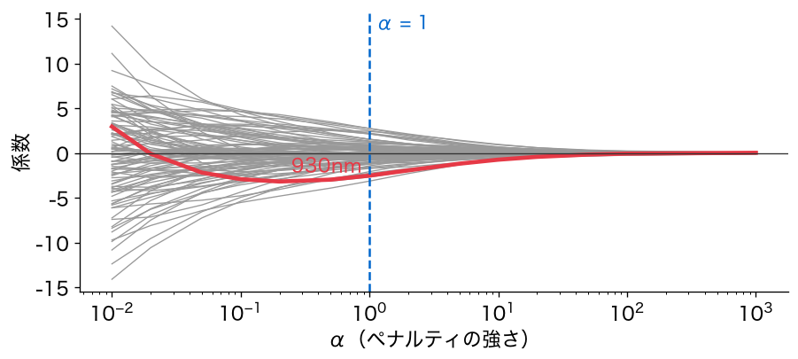

- α=1では、係数はまだ0ではない。暴れは収まり、形は残っている
- 交差検証は、暴れすぎと縮めすぎの間を選んでいる

## 重要：αは交差検証で選ぶ

4節 ⑦ 重要●

係数はデータが決める。ハイパーパラメータ（α）は、人が候補を並べ、交差検証で比べて選ぶ。

## TODO③：αの候補を足す

4節 ⑧ 候補を足す●

```python
# TODO: 0.3 を別の数（たとえば 3 や 0.03）に替えて実行する
a = 0.3
maes[a] = np.mean(cv_mae(df, waves, Ridge(alpha=a)))
print(a, round(maes[a], 2))
```

- 予想：$\alpha = 0.3$は、1より良い？ 悪い？

## ここまでで分かったこと

4節 ⑨ 分かったこと●

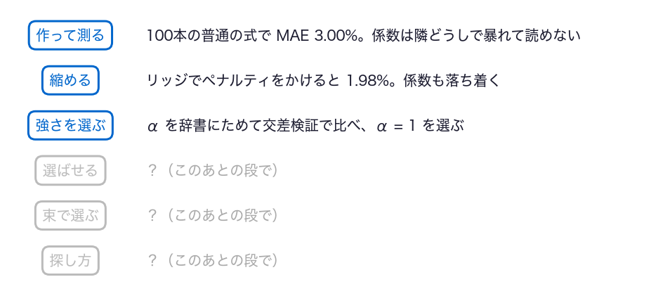

- まだ分からない：100本のうち、どの波長が脂肪を教えているか

## ノートへ：4節

4節 10 ノートへ●

- 4節のセルを上から実行し、スライドと同じ数が出るか確かめる
- TODO③：予想を書く → `a`を替えて実行 → 予想と比べる

動画の人は、ここで一時停止。

## 答え合わせ：TODO③

4節 11 答え合わせ●○

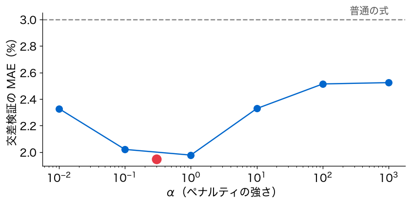

```
α = 0.3 1.95
```

- $\alpha = 0.3$は1.95%で、1の1.98%より少し良い

## 候補の並べ方しだい

4節 11 答え合わせ●●

- 候補にない$\alpha$は、選べない
- まず10倍ごとに粗く並べ、良さそうなあたりを細かく足す
- ただ、1.95%と1.98%の差は、組の分け方で揺れる程度の小さな差

# 5. 効く波長だけ残せる？

## 段4：選ばせる

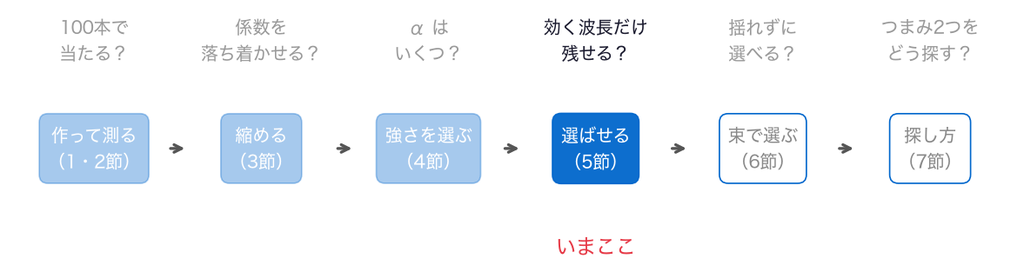

- 問い：100本のうち、効く波長だけを残せるか
- リッジの係数は落ち着いたが、100本すべてが0でない

## 前の段から

5節 ① 前の段から●

- ペナルティの強さは、交差検証で選べた
- でもリッジは、どの係数も小さくするだけで、ちょうど0にはしない
- 説明に使うなら、効く波長だけが残ってほしい

## ペナルティを、絶対値の和に替える

5節 ② ラッソ●○○

$$\sum_{i=1}^{n} (y_i - \hat{y}_i)^2 + \alpha \sum_{j=1}^{100} \lvert b_j \rvert$$

- 二乗の和の代わりに、係数の絶対値の和にペナルティをかける
- この線形回帰を、ラッソ（lasso）と呼ぶ

## ペナルティの谷に、角ができる

5節 ② ラッソ●●○

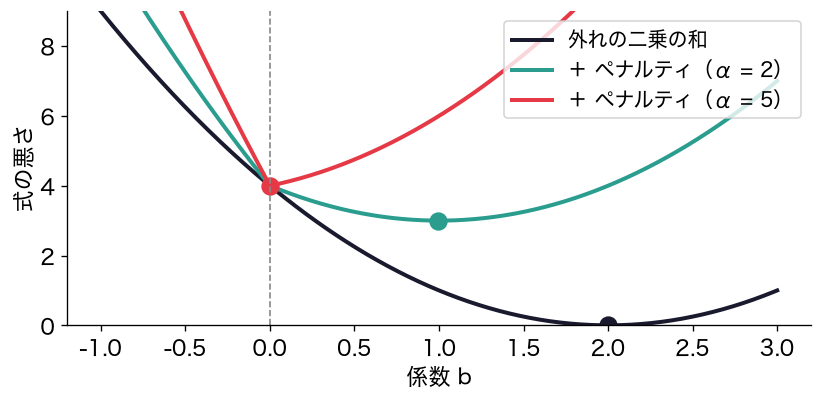

- 絶対値のペナルティは、$b = 0$で折れ曲がる。強くすると、谷底がちょうど0に止まる

## 0になった波長は、式から消える

5節 ② ラッソ●●●

- 係数が0の波長は、予測に使われない
- $\alpha$を大きくするほど、0になる波長が増え、残る波長が減る
- ラッソは、係数を縮めながら、波長を選ぶ

## お手本：ラッソで残る波長

5節 ③ ラッソで選ぶ●○

```python
m_l = Lasso(alpha=100, max_iter=100000)
m_l.fit(df[waves], df['脂肪'])
coef_l = pd.Series(m_l.coef_, index=waves)
print(list(coef_l[coef_l != 0].index))
print(round(np.mean(cv_mae(df, waves, m_l)), 2))
```

```
['870', '872', '874', '930', '956']
3.89
```

- `max_iter`：計算をくり返す上限。似た列が多いと、多めに要る

## 100本から5本に

5節 ③ ラッソで選ぶ●●

- 残ったのは870・872・874・930・956nmの5本
- 外れは3.89%。リッジの1.98%より悪いが、5本だけで当てている
- これで「効く波長」が分かった？

## ラッソの解パス

5節 ④ ラッソの解パス●○

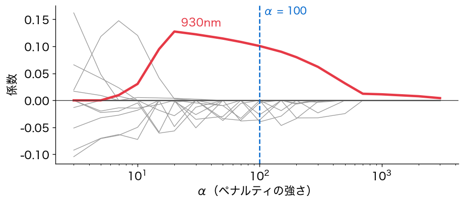

- 右（強い）から左へ、αを弱めていく向きに読む
- 0だった係数が1本ずつ0から離れ、波長が式に入ってくる

## 最後まで残るのは930nm

5節 ④ ラッソの解パス●●

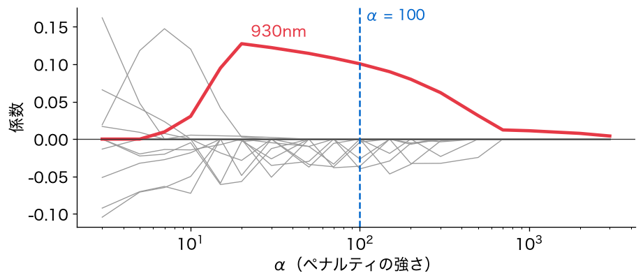

- いちばん強いαまで残るのは、930nmの1本
- ほかの灰色の線は短い。αを少し変えるだけで、隣の波長と入れ替わる

## 肉を取り直すと？

5節 ⑤ 取り直す●○○

- 本当に効く波長なら、肉が少し違っても、同じ波長が選ばれるはず
- 120個から96個をくじで取り直し、ラッソで選び直す
- 20回くり返して、波長ごとに選ばれた回数を数える

## お手本：1回分の選ばれた波長

5節 ⑤ 取り直す●●○

```python
def picked(model, s):
    sub = df.sample(96, random_state=s)
    model.fit(sub[waves], sub['脂肪'])
    coef = pd.Series(model.coef_, index=waves)
    return list(coef[coef != 0].index)

for s in range(3):
    print(picked(Lasso(alpha=100, max_iter=100000), s))
```

```
['868', '870', '872', '930', '956', '958']
['868', '870', '872', '930', '956']
['870', '872', '930', '956']
```

## 選ぶ波長が、少しずつ違う

5節 ⑤ 取り直す●●●

## おさらい：辞書

5節 ⑥ 回数を数える●○○○○○○

```python
d = {}             # 空の辞書
d['りんご'] = 120   # 名札'りんご'に120をしまう
print(d['りんご'])  # 120
```

- 名札（キー）と中身（値）の組をためる。`d[キー]`で取り出す（4節）

## お手本：波長ごとに数える

5節 ⑥ 回数を数える●●○○○○○

```python
counts = {}
for w in waves:
    counts[w] = 0                    # 100本の名札を0で用意
for s in range(20):
    for w in picked(Lasso(alpha=100, max_iter=100000), s):
        counts[w] = counts[w] + 1    # 選ばれた波長に1を足す
print(counts['868'], counts['870'], counts['872'], counts['874'])
```

```
7 20 18 12
```

- 名札は波長。選ばれるたびに、その波長の引き出しの数を1つ増やす

## 1行ずつ：波長ごとに数える①

5節 ⑥ 回数を数える●●●○○○○

```python
counts = {}
for w in waves:
    counts[w] = 0                    # 100本の名札を0で用意
for s in range(20):
    for w in picked(Lasso(alpha=100, max_iter=100000), s):
        counts[w] = counts[w] + 1    # 選ばれた波長に1を足す
print(counts['868'], counts['870'], counts['872'], counts['874'])
```

- 1行目：空の辞書を作り、`counts`と名付ける
- 2・3行目：100本の波長`w`を1本ずつ名札にして、中身を0にする
- 先に0を入れておくのは、4〜6行目で「今の数に1を足す」ため

## 1行ずつ：波長ごとに数える②

5節 ⑥ 回数を数える●●●●○○○

```python
counts = {}
for w in waves:
    counts[w] = 0                    # 100本の名札を0で用意
for s in range(20):
    for w in picked(Lasso(alpha=100, max_iter=100000), s):
        counts[w] = counts[w] + 1    # 選ばれた波長に1を足す
print(counts['868'], counts['870'], counts['872'], counts['874'])
```

- 4行目：くじの番号`s`を0から19まで変え、取り直しを20回くり返す
- 5行目：その回に選ばれた波長のリストから、1本ずつ`w`に取り出す
- 外の`for`は回、中の`for`はその回に選ばれた波長

## 1行ずつ：波長ごとに数える③

5節 ⑥ 回数を数える●●●●●○○

```python
counts = {}
for w in waves:
    counts[w] = 0                    # 100本の名札を0で用意
for s in range(20):
    for w in picked(Lasso(alpha=100, max_iter=100000), s):
        counts[w] = counts[w] + 1    # 選ばれた波長に1を足す
print(counts['868'], counts['870'], counts['872'], counts['874'])
```

- 6行目：右側で名札`w`の今の数を取り出して1を足し、同じ名札にしまい直す
- 7行目：4本の波長の名札を開けて、選ばれた回数を出す

## 中身を見る：3回まわした数

5節 ⑥ 回数を数える●●●●●●○

```python
counts3 = {}
for w in waves:
    counts3[w] = 0
for s in range(3):
    for w in picked(Lasso(alpha=100, max_iter=100000), s):
        counts3[w] = counts3[w] + 1
    print(s, counts3['868'], counts3['874'])
```

```
0 1 0
1 2 0
2 2 0
```

- 左から、くじの番号`s`（0が1回目）、868nmの数、874nmの数
- 868nmは、1・2回目に選ばれて1、2と増え、3回目は選ばれず2のまま
- 874nmは、3回とも選ばれず0のまま

## お手本：回数を棒で描く

5節 ⑥ 回数を数える●●●●●●●

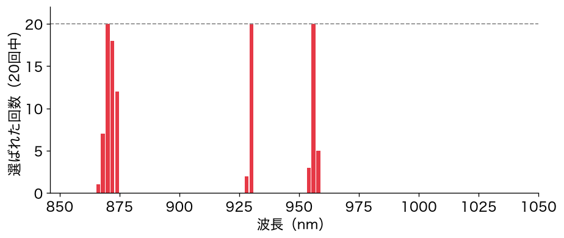

```python
plt.bar(nm, list(counts.values()), width=1.6)
plt.xlabel('波長（nm）')
plt.ylabel('選ばれた回数（20回中）')
plt.show()
```